# The Base Plotting System

The core plotting and graphics engine in R is encapsulated in the following packages:

- `graphics`: contains code for actually constructing and annotating plots. It contains plotting functions for the “base” graphing systems, including `plot`, `hist`, `boxplot` and many others.
- `grDevices`: contains all the code implementing the various graphics devices, including X11, PDF, PostScript, PNG, etc.

Base graphics are created in two phases:

1. Initializing a new plot
2. Annotating an existing plot

## 1. Some important base graphics parameters

Many base plotting functions share a set of global parameters. Here are a few key ones:

- `pch`: plotting character (default is open circle)
- `lty`: line type (default is solid line)
- `lwd`: line width, specified as an integer multiple
- `col`: color, specified as number, string, or hex code
- `xlab`: character string for x-axis label
- `ylab`: character string for y-axis label
- `main`: character string for title

The `par()` function is used to specify the *global* graphics parameters that affect all plots in an R session. These parameters can be overridden when they are specified as arguments to specific plotting functions (except for `mfrow` and `mfcol`, which are only available to the `par()` function.)

- `las`: orientation of the axis labels on the plot
- `bg`: background color
- `mar`: margin size, numeric vector of the form `c(bottom, left, top, right)`
- `oma`: outer margin size
- `mfrow`: number of plots per row, column (plots are filled row-wise)
- `mfcol`: number of plots per row, column (plots are filled column-wise)

You can see the default values for global graphics parameters by calling the `par()` function and passing the name of the parameter in quotes.

```
> par("lty")
[1] "solid"
> par("mar")
[1] 5.1 4.1 4.1 2.1
> par("oma")
[1] 0 0 0 0
```

## 2. Base plotting functions

The most basic base plotting function is `plot()`. The `plot()` function makes a scatterplot, or other type of plot depending on the class of th object being plotted. (`plot()` is what’s called a *generic function* in R, which means its behavior can change depending on what kinds of data are passed to the function.)

Calling `plot()` will draw a plot on the screen device, after that, annotation functions can be called to add to the already-made plot. Some key annotation functions are

- `lines`: add lines to a plot, given a vector of `x` values and a corresponding vector of `y` values (or a 2-column matrix); this function just connects the dots
- `points`: add points to a plot
- `text`: add text labels to a plot using specified x, y coordinates (adding text inside the plot)
- `title`: add annotations to x, y axis label, title, subtitle, outer margin (adding text outside the plot)
- `mtext`: add arbitrary text to the margins (inner or outer) of the plot
- `axis`: add axis ticks/labels
- `abline`: add one or more straight lnes through the plot

## 3. Examples

#### 3.1 Boxplot

Boxplots can be made in R using the `boxplot()` function, which takes as its first argument a *formula* of the form of `y-axis ~ x-axis`.

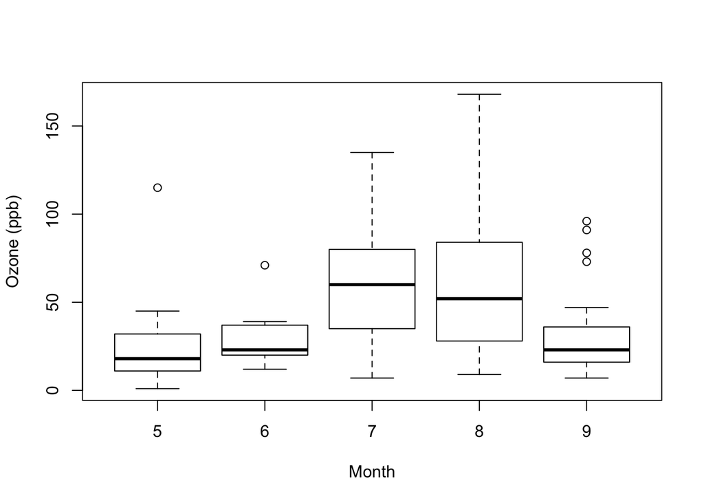

```r
library(datasets)
#airquality <- transform(airquality, Month = factor(Month))
boxplot(Ozone ~ Month, airquality, xlab = "Month", ylab = "Ozone (ppb)")
```

#### 3.2 Histogram

Here is a simple univariate histogram.

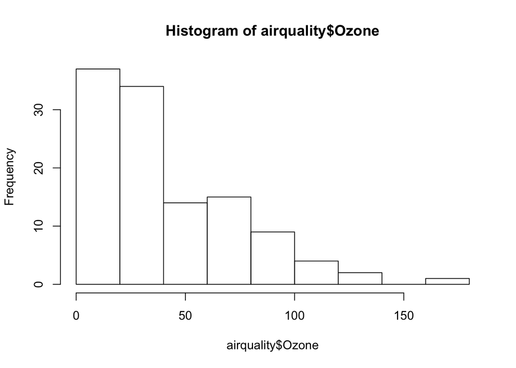

```r
hist(airquality$Ozone)
```

#### 3.3 Scatterplot

First we make the plot with the `plot()` function, then we add a title to the top with the `title()` function.

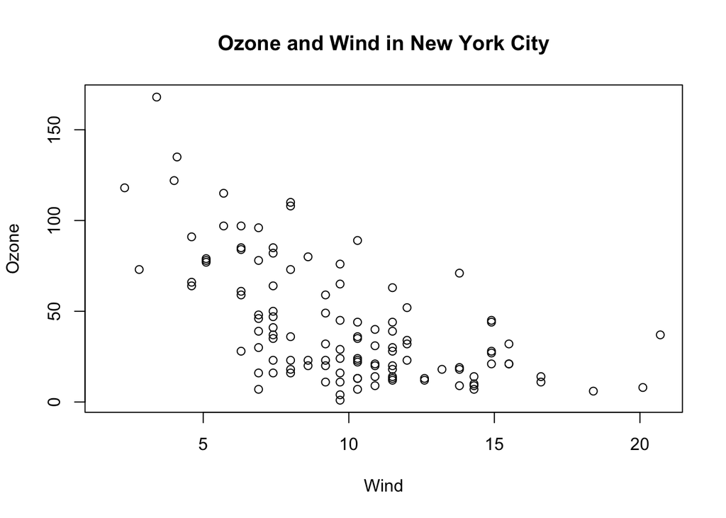

```r
library(datasets)
## Make the initial plot
with(airquality, plot(Wind, Ozone))
## Add a title
title(main = "Ozone and Wind in New York City")
```

Next we create the same plot as above, and then annotate it by coloring blue the data points corresponding to the month of May.

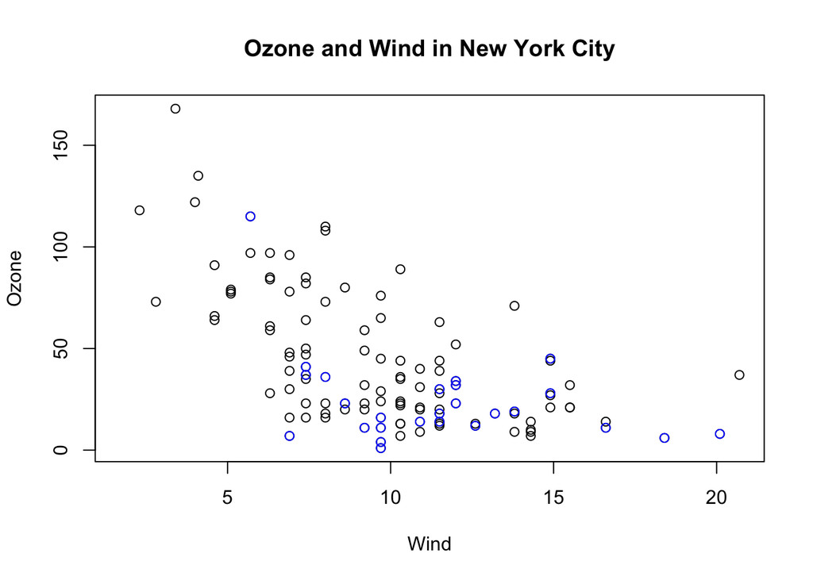

```r
with(airquality, plot(Wind, Ozone, main = "Ozone and Wind in New York City"))
with(subset(airquality, Month == 5), points(Wind, Ozone, col = "blue"))
```

Next we construct an initial plot with the option `type = n` (for no plotting) in the call to `plot()`. This is a common paradigm as `plot()` will draw everything except for the data points inside the plot window. We can then use annotation functions like `points()` and `legend()` to add additional elements, including the data points.

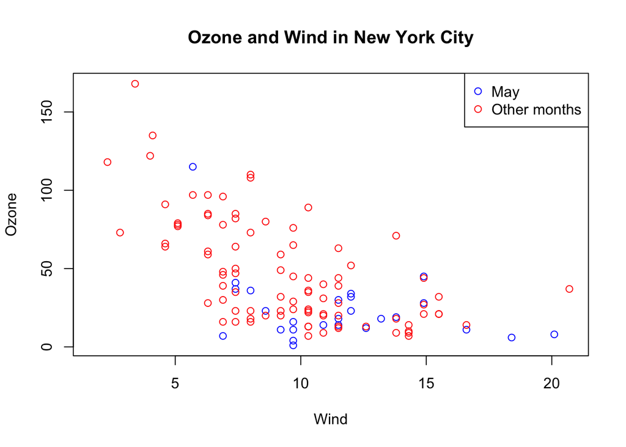

```r
with(airquality, plot(Wind, Ozone, main = "Ozone and Wind in New York City", type = "n"))
with(subset(airquality, Month == 5), points(Wind, Ozone, col = "blue"))
with(subset(airquality, Month != 5), points(Wind, Ozone, col = "red"))
legend("topright", pch = 1, col = c("blue", "red"), legend = c("May", "Other months"))
```

#### 3.4 Base plot with regression line

It’s common to make a scatterplot and then want to draw a simple linear regression line through the data. this can be done with the `abline()` function.

We first make the plot, then fit a simple linear regression model with the `lm()` function. Then we pass the output of `lm()` to the `abline()` function, which automatically takes the information from the `model` object and calculates the corresponding regression line.

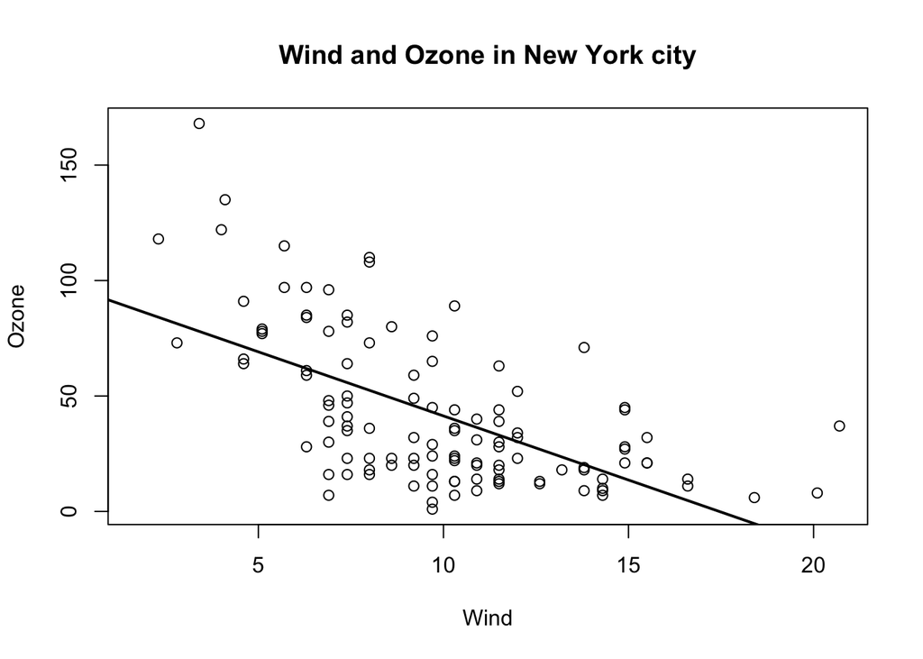

```r
with(airquality, plot(Wind, Ozone, main = "Wind and Ozone in New York city"))
## fit a simple linear regression model
model <- with(airquality, lm(Ozone ~ Wind))
## Draw regression line
abline(model, lwd = 2)
```

#### 3.5 Multiple base plots

Both `mfrow` and `mfcol` parameters take two numbers: number of rows followed by number of columns. The only difference between the two parameters is that `mfrow` will draw plots row-wise, whereas `mfcol` will draw plots column-wise.

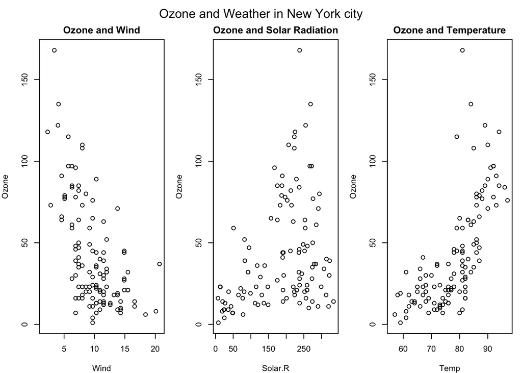

```r
par(mfrow = c(1, 3), mar = c(4, 4, 2, 1), oma = c(0, 0, 2, 0))
with(airquality, {
  plot(Wind, Ozone, main = "Ozone and Wind")
  plot(Solar.R, Ozone, main = "Ozone and Solar Radiation")
  plot(Temp, Ozone, main = "Ozone and Temperature")
  mtext("Ozone and Weather in New York city", outer = TRUE)
})
```